# Reproducible Research Project

Karan Vijay Kashyap

2022-06-16

Article Title: Determinant of Human Development Index in ASEAN Countries The development debate is about more than just per capita income increase. Development is a multifaceted concept that encompasses many aspects of the community. According to Sarkar et al. (2012), human development is one of the most important factors in determining a country’s degree of development. In 1990, the Human Development Index (HDI) was first released. It assesses longevity and health, as well as knowledge and a reasonable way of living. The HDI employs the logarithm of income to illustrate the decreasing relevance of income as GNP rises.

# Introduction

The development debate is about more than just per capita income increase. Development is a multifaceted concept that encompasses many aspects of the community. According to Sarkar et al. (2012), human development is one of the most important factors in determining a country’s degree of development. In 1990, the Human Development Index (HDI) was first released. It assesses longevity and health, as well as knowledge and a reasonable way of living. The HDI employs the logarithm of income to illustrate the decreasing relevance of income as GNP rises.

## About Data

In this project, I have found the data on worlddatabank, I selected 10 countries which were discussed in the article and 6 rows names Inflation, Unemployment, GDP Per capita Growth, GDP Growth, Population and Human Development Index from 2000 to 2015. It was very complex to find this data as everything was not present on one place.

## Objective of study

The main objective of this study is to reproduce the same result by applying fixed effect model and random effect model and compare the both the model, Later replicate the same model using new dataset. The main purpose of this study is to understand how reproducible research is done.

# Data Analysis

```r
library(readxl)
Data <- read_excel("C:\\Users\\ASUS\\Desktop\\Reproducible-Research-Project\\Data.xlsx")
head(Data)
```

| Country | Year | Inflation | Unemployment | GDP per capita growth | GDP growth | Population | HDI |
| --- | --- | --- | --- | --- | --- | --- | --- |
| Thailand | 2000 [YR2000] | 1.591969 | 2.39 | 3.369970 | 4.455247 | 62952639 | 0.652 |
| Thailand | 2001 [YR2001] | 1.626909 | 2.60 | 2.489321 | 3.444249 | 63539190 | 0.660 |
| Thailand | 2002 [YR2002] | 0.697309 | 1.82 | 5.271098 | 6.149036 | 64069093 | 0.669 |
| Thailand | 2003 [YR2003] | 1.804350 | 1.54 | 6.390887 | 7.189243 | 64549867 | 0.677 |
| Thailand | 2004 [YR2004] | 2.759149 | 1.51 | 5.560903 | 6.289342 | 64995303 | 0.686 |
| Thailand | 2005 [YR2005] | 4.540369 | 1.35 | 3.517298 | 4.187638 | 65416189 | 0.696 |

The summary function shows that the min value, Max value, and mean value for each variable which is very significant.we can clearly see that the data is spreaded in larger range.

```r
summary(Data)
```

```
##    Country              Year             Inflation       Unemployment
##  Length:160         Length:160         Min.   :-2.315   Min.   :0.250
##  Class :character   Class :character   1st Qu.: 1.341   1st Qu.:0.992
##  Mode  :character   Mode  :character   Median : 3.649   Median :2.820
##                                        Mean   : 5.304   Mean   :2.972
##                                        3rd Qu.: 6.439   3rd Qu.:3.982
##                                        Max.   :57.075   Max.   :8.060
##  GDP per capita growth   GDP growth       Population             HDI
##  Min.   :-3.785        Min.   :-2.508   Min.   :   333166   Min.   :0.4140
##  1st Qu.: 2.921        1st Qu.: 4.394   1st Qu.:  6021210   1st Qu.:0.5585
##  Median : 4.601        Median : 6.022   Median : 38495332   Median :0.6650
##  Mean   : 4.350        Mean   : 5.842   Mean   : 57826050   Mean   :0.6633
##  3rd Qu.: 5.919        3rd Qu.: 7.375   3rd Qu.: 83054682   3rd Qu.:0.7428
##  Max.   :12.722        Max.   :14.526   Max.   :258383257   Max.   :0.9310
```

```r
str(Data)
```

```
## tibble [160 x 8] (S3: tbl_df/tbl/data.frame)
##  $ Country              : chr [1:160] "Thailand" "Thailand" "Thailand" "Thailand" ...
##  $ Year                 : chr [1:160] "2000 [YR2000]" "2001 [YR2001]" "2002 [YR2002]" "2003 [YR2003]" ...
##  $ Inflation            : num [1:160] 1.592 1.627 0.697 1.804 2.759 ...
##  $ Unemployment         : num [1:160] 2.39 2.6 1.82 1.54 1.51 ...
##  $ GDP per capita growth: num [1:160] 3.37 2.49 5.27 6.39 5.56 ...
##  $ GDP growth           : num [1:160] 4.46 3.44 6.15 7.19 6.29 ...
##  $ Population           : num [1:160] 62952639 63539190 64069093 64549867 64995303 ...
##  $ HDI                  : num [1:160] 0.652 0.66 0.669 0.677 0.686 0.696 0.697 0.714 0.718 0.722 ...
```

We can see that we dont have any missing value in our Dataset.

```r
sapply(Data, function(x) sum(is.na(x)))
```

```
##               Country                  Year             Inflation
##                     0                     0                     0
##          Unemployment GDP per capita growth            GDP growth
##                     0                     0                     0
##            Population                   HDI
##                     0                     0
```

# Data Visualization

The below histogram will help us to check the normality of the data, The histogram seems to be skewed but overall it looks good and we can proceed with it.

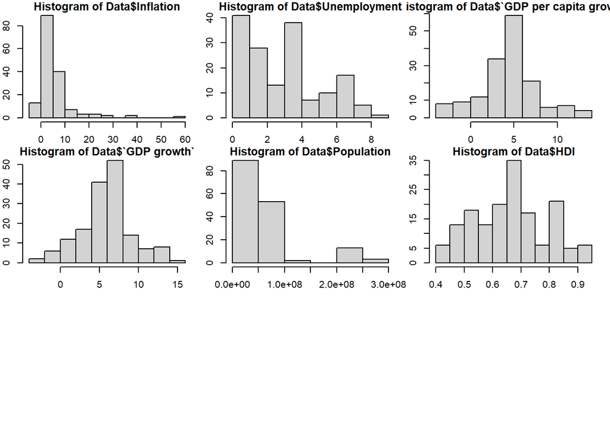

```r
par(mfrow=c(3,3))
par(mar=c(2,2,1,1))
hist(Data$Inflation)
hist(Data$Unemployment)
hist(Data$`GDP per capita growth`)
hist(Data$`GDP growth`)
hist(Data$Population)
hist(Data$HDI)
```

# Methodology from the Research Paper The first, run the estimation using fixed-effect model. Second, do the Chow-test to choose between pooled ordinary least square or fixed effect model . After that using the Chow-test we can see that we reject or accept the null hypothesis depending on our results

The next step we estimate the equation with random effect model. After that using the using the Hausman-test, we can see that we reject or accept the null hypothesis depending on our results

We will apply the exactly same methodology in our reproducible research and will try to find similar results as that of our research paper.

# Logarithm Data

```r
logData <- Data

logData$Inflation <- log(Data$Inflation + 2.5)
logData$Unemployment <- log(Data$Unemployment )
logData$`GDP per capita growth` <- log(Data$`GDP per capita growth` + 4)
logData$`GDP growth`<- log(Data$`GDP growth` + 3)
logData$Population <- log(Data$Population)
logData$HDI <- log(Data$HDI)
```

# Fixed effects model

Fixed-effects models are a class of statistical models in which the levels (i.e., values) of independent variables are assumed to be fixed (i.e., constant), and only the dependent variable changes in response to the levels of independent variables

From the below results, we can conclude that variable inflation, `GDP growth`and `GDP per capita growth` is insignificant, whereas variable Unemployment and Population. Moreover we can see that p-value: 2.22e-16 is less than significance level of 0.05 thus rejects the null hypothesis.

```r
#install.packages("plm")
#library("plm")
fixed <- plm(HDI~Inflation+Unemployment+logData$`GDP per capita growth`+logData$`GDP growth`+Population,
            data=logData, index=c("Country", "Year"), model="within")
summary(fixed)
```

```
## Oneway (individual) effect Within Model
##
## Call:
## plm(formula = HDI ~ Inflation + Unemployment + logData$`GDP per capita growth` +
##     logData$`GDP growth` + Population, data = logData, model = "within",
##     index = c("Country", "Year"))
##
## Balanced Panel: n = 10, T = 16, N = 160
##
## Residuals:
##        Min.     1st Qu.      Median     3rd Qu.        Max.
## -0.12388957 -0.01238605 -0.00026027  0.01443830  0.10084457
##
## Coefficients:
##                                   Estimate Std. Error t-value  Pr(>|t|)
## Inflation                        0.0001688  0.0046073  0.0366    0.9708
## Unemployment                    -0.0454773  0.0102301 -4.4455 1.732e-05 ***
## logData$`GDP per capita growth`  0.0102744  0.0136570  0.7523    0.4531
## logData$`GDP growth`            -0.0205678  0.0189522 -1.0852    0.2796
## Population                       0.5790265  0.0436870 13.2540 < 2.2e-16 ***
## ---
## Signif. codes:  0 '***' 0.001 '**' 0.01 '*' 0.05 '.' 0.1 ' ' 1
##
## Total Sum of Squares:    0.54722
## Residual Sum of Squares: 0.16131
## R-Squared:      0.70522
## Adj. R-Squared: 0.67676
## F-statistic: 69.38 on 5 and 145 DF, p-value: < 2.22e-16
```

# OLS

```r
OLS <- plm(HDI~Inflation+Unemployment+logData$`GDP per capita growth`+logData$`GDP growth`+Population,
            data=logData, index=c("Country", "Year"), model="pooling")
summary(OLS)
```

```
## Pooling Model
##
## Call:
## plm(formula = HDI ~ Inflation + Unemployment + logData$`GDP per capita growth` +
##     logData$`GDP growth` + Population, data = logData, model = "pooling",
##     index = c("Country", "Year"))
##
## Balanced Panel: n = 10, T = 16, N = 160
##
## Residuals:
##       Min.    1st Qu.     Median    3rd Qu.       Max.
## -0.4151397 -0.0695733 -0.0026255  0.0825824  0.3936435
##
## Coefficients:
##                                   Estimate Std. Error t-value  Pr(>|t|)
## (Intercept)                     -0.2667534  0.1118421 -2.3851   0.01829 *
## Inflation                       -0.0676069  0.0166740 -4.0546  7.95e-05 ***
## Unemployment                     0.1314118  0.0137066  9.5875 < 2.2e-16 ***
## logData$`GDP per capita growth`  0.0843014  0.0524617  1.6069   0.11012
## logData$`GDP growth`            -0.0705593  0.0686385 -1.0280   0.30557
## Population                      -0.0096999  0.0073772 -1.3148   0.19052
## ---
## Signif. codes:  0 '***' 0.001 '**' 0.01 '*' 0.05 '.' 0.1 ' ' 1
##
## Total Sum of Squares:    6.2508
## Residual Sum of Squares: 2.9902
## R-Squared:      0.52163
## Adj. R-Squared: 0.5061
## F-statistic: 33.5854 on 5 and 154 DF, p-value: < 2.22e-16
```

# Perform Chow test

```r
sctest(logData$HDI ~ logData$Inflation+ logData$Unemployment+logData$`GDP per capita growth`+logData$`GDP growth`+logData$Population, type = "Chow", point = 10)
```

```
##
##  Chow test
##
## data:  logData$HDI ~ logData$Inflation + logData$Unemployment + logData$`GDP per capita growth` +     logData$`GDP growth` + logData$Population
## F = 1.0861, p-value = 0.3734
```

# Random Effect Model

```r
#install.packages("plm")
#library("plm")
Random <- plm(HDI~Inflation+Unemployment+logData$`GDP per capita growth`+logData$`GDP growth`+Population,
            data=logData, index=c("Country", "Year"), model="random")
summary(Random)
```

```
## Oneway (individual) effect Random Effect Model
##    (Swamy-Arora's transformation)
##
## Call:
## plm(formula = HDI ~ Inflation + Unemployment + logData$`GDP per capita growth` +
##     logData$`GDP growth` + Population, data = logData, model = "random",
##     index = c("Country", "Year"))
##
## Balanced Panel: n = 10, T = 16, N = 160
##
## Effects:
##                    var  std.dev share
## idiosyncratic 0.001112 0.033354 0.078
## individual    0.013113 0.114510 0.922
## theta: 0.9274
##
## Residuals:
##       Min.    1st Qu.     Median    3rd Qu.       Max.
## -0.1810601 -0.0272916  0.0063392  0.0329061  0.0915994
##
## Coefficients:
##                                   Estimate Std. Error z-value  Pr(>|z|)
## (Intercept)                     -1.5387216  0.4813007 -3.1970  0.001389 **
## Inflation                        0.0028836  0.0069746  0.4134  0.679284
## Unemployment                    -0.0839600  0.0141187 -5.9467 2.735e-09 ***
## logData$`GDP per capita growth`  0.0419928  0.0204027  2.0582  0.039571 *
## logData$`GDP growth`            -0.0765170  0.0279981 -2.7329  0.006277 **
## Population                       0.0736586  0.0280404  2.6269  0.008617 **
## ---
## Signif. codes:  0 '***' 0.001 '**' 0.01 '*' 0.05 '.' 0.1 ' ' 1
##
## Total Sum of Squares:    0.57731
## Residual Sum of Squares: 0.39514
## R-Squared:      0.31555
## Adj. R-Squared: 0.29332
## Chisq: 70.9973 on 5 DF, p-value: 6.3538e-14
```

# Hausman Test

Results of the Haussman test, which compares the fixed effect model versus the random effect model. The Hausman test yields a significant result. The results show that using a fixed effect model rather than a random effect model makes the results more stable. As a result, the fixed effect model will be used in this study to estimate the drivers of factors impacting the human development index in 10 ASEAN member nations. The observation was carried out over a period of 16 years in 10 ASEAN nations, for a total of 160 observations.

# Hausman Result from the Research Paper which is very similar to our results

chisq df p-value 257.9291 4.0000 0.0000

Our Results: chisq = 226.83, df = 5, p-value < 2.2e-16

```r
phtest(fixed, Random)
```

```
##
##  Hausman Test
##
## data:  HDI ~ Inflation + Unemployment + logData$`GDP per capita growth` +  ...
## chisq = 226.83, df = 5, p-value < 2.2e-16
## alternative hypothesis: one model is inconsistent
```

# Final Results of Reproducible Research on Original Dataset.

I would like to conclude that the results are quite similar for fixed effect mode, ols model, random model and hausman to that of research paper but chow test is not similar as in our paper we accept the null hypothesis while in research paper we have to reject the null hypothesis, which is very strange as chow test is used to choose between fixed and ols model, we can clearly see that fixed model outperforms ols model from our results.

# Applying same model on a new dataset with 10 different country chosed from extended paper.

```r
library(readxl)
NewData <- read_excel("NewData.xlsx")
View(NewData)
```

# Data Analysis (New Dataset)

```r
head(NewData)
```

| Country | Year | Inflation | Unemployment | GDP per capita growth | GDP growth | Population | HDI |
| --- | --- | --- | --- | --- | --- | --- | --- |
| Maldives | 2000 [YR2000] | -1.1747568 | 1.970 | 1.662564 | 3.845810 | 279396 | 0.622 |
| Maldives | 2001 [YR2001] | 0.6725774 | 2.997 | -6.262939 | -3.943634 | 286309 | 0.626 |
| Maldives | 2002 [YR2002] | 4.1786724 | 4.188 | 4.396568 | 7.268386 | 294185 | 0.630 |
| Maldives | 2003 [YR2003] | -1.2606511 | 5.394 | 10.557182 | 13.750050 | 302681 | 0.644 |
| Maldives | 2004 [YR2004] | -1.6854121 | 6.416 | 3.109578 | 6.033754 | 311265 | 0.649 |
| Maldives | 2005 [YR2005] | 1.3002750 | 7.201 | -15.395661 | -13.129053 | 319604 | 0.645 |

```r
summary(NewData)
```

```
##    Country              Year             Inflation        Unemployment
##  Length:159         Length:159         Min.   :-18.109   Min.   : 0.250
##  Class :character   Class :character   1st Qu.:  3.104   1st Qu.: 1.214
##  Mode  :character   Mode  :character   Median :  5.643   Median : 3.320
##                                        Mean   :  6.649   Mean   : 3.695
##                                        3rd Qu.:  8.536   3rd Qu.: 5.545
##                                        Max.   : 57.075   Max.   :11.700
##  GDP per capita growth   GDP growth        Population             HDI
##  Min.   :-15.396       Min.   :-13.129   Min.   :2.794e+05   Min.   :0.2930
##  1st Qu.:  3.252       1st Qu.:  4.656   1st Qu.:1.378e+07   1st Qu.:0.4985
##  Median :  4.795       Median :  6.105   Median :2.704e+07   Median :0.6090
##  Mean   :  4.855       Mean   :  6.276   Mean   :1.737e+08   Mean   :0.5921
##  3rd Qu.:  6.190       3rd Qu.:  7.769   3rd Qu.:1.418e+08   3rd Qu.:0.7030
##  Max.   : 23.075       Max.   : 26.111   Max.   :1.310e+09   Max.   :0.7760
```

```r
str(NewData)
```

```
## tibble [159 x 8] (S3: tbl_df/tbl/data.frame)
##  $ Country              : chr [1:159] "Maldives" "Maldives" "Maldives" "Maldives" ...
##  $ Year                 : chr [1:159] "2000 [YR2000]" "2001 [YR2001]" "2002 [YR2002]" "2003 [YR2003]" ...
##  $ Inflation            : num [1:159] -1.175 0.673 4.179 -1.261 -1.685 ...
##  $ Unemployment         : num [1:159] 1.97 3 4.19 5.39 6.42 ...
##  $ GDP per capita growth: num [1:159] 1.66 -6.26 4.4 10.56 3.11 ...
##  $ GDP growth           : num [1:159] 3.85 -3.94 7.27 13.75 6.03 ...
##  $ Population           : num [1:159] 279396 286309 294185 302681 311265 ...
##  $ HDI                  : num [1:159] 0.622 0.626 0.63 0.644 0.649 0.645 0.659 0.664 0.673 0.674 ...
```

```r
sapply(NewData, function(x) sum(is.na(x)))
```

```
##               Country                  Year             Inflation
##                     0                     0                     0
##          Unemployment GDP per capita growth            GDP growth
##                     0                     0                     0
##            Population                   HDI
##                     0                     0
```

# Log Transformation (New Dataset)

```r
NewlogData <- NewData

NewlogData$Inflation <- log(NewData$Inflation + 19)
NewlogData$Unemployment <- log(NewData$Unemployment )
NewlogData$`GDP per capita growth` <- log(NewData$`GDP per capita growth` + 16)
NewlogData$`GDP growth`<- log(NewData$`GDP growth` + 14)
NewlogData$Population <- log(NewData$Population)
NewlogData$HDI <- log(NewData$HDI)
```

# Method (New Dataset)

The fixed-effect model is used to estimate the first step in this research. The Chow-test is then used to determine whether we reject the null hypothesis or not. The equation is then estimated using a random effect model. Using the Hausman-test, we can observe that we reject the null hypothesis, which stated whether or not the random effect model is consistent. We will apply same method as applied in our research paper but with new dataset to compare the results and understand the difference when comparing different HDI countries.

# Fixed Effect Model (New Dataset)

From the below results, we can conclude that variable inflation is insignificant, whereas variable Unemployment, `GDP growth',`GDP per capita growth and Population. Moreover we can see that p-value: 2.22e-16 is less than significance level of 0.05 thus rejects the null hypothesis.

```r
#install.packages("plm")
#library("plm")
Newfixed <- plm(HDI~Inflation+Unemployment+NewlogData$`GDP per capita growth`+NewlogData$`GDP growth`+Population,
            data=NewlogData, index=c("Country", "Year"), model="within")
summary(Newfixed)
```

```
## Oneway (individual) effect Within Model
##
## Call:
## plm(formula = HDI ~ Inflation + Unemployment + NewlogData$`GDP per capita growth` +
##     NewlogData$`GDP growth` + Population, data = NewlogData,
##     model = "within", index = c("Country", "Year"))
##
## Unbalanced Panel: n = 10, T = 15-16, N = 159
##
## Residuals:
##        Min.     1st Qu.      Median     3rd Qu.        Max.
## -0.15223776 -0.02237676  0.00086375  0.02588106  0.11811325
##
## Coefficients:
##                                      Estimate Std. Error t-value  Pr(>|t|)
## Inflation                          -0.0068533  0.0113283 -0.6050   0.54615
## Unemployment                       -0.0287570  0.0110563 -2.6009   0.01027 *
## NewlogData$`GDP per capita growth` -0.6071223  0.1379191 -4.4020 2.076e-05 ***
## NewlogData$`GDP growth`             0.6530049  0.1469199  4.4446 1.745e-05 ***
## Population                          0.9196841  0.0543277 16.9285 < 2.2e-16 ***
## ---
## Signif. codes:  0 '***' 0.001 '**' 0.01 '*' 0.05 '.' 0.1 ' ' 1
##
## Total Sum of Squares:    0.84267
## Residual Sum of Squares: 0.27748
## R-Squared:      0.67071
## Adj. R-Squared: 0.6387
## F-statistic: 58.6612 on 5 and 144 DF, p-value: < 2.22e-16
```

# OLS (New Dataset)

From the below results, we can conclude that variable inflation is insignificant, whereas variable Unemployment, `GDP growth',`GDP per capita growth and Population. Moreover we can see that p-value: 2.22e-16 is less than significance level of 0.05 thus rejects the null hypothesis. The ols result for newdata set is quite similar to that of fixed model. which is a good sign as both the model have same significant variable.

```r
OLS <- plm(HDI~Inflation+Unemployment+NewlogData$`GDP per capita growth`+NewlogData$`GDP growth`+Population,
            data=NewlogData, index=c("Country", "Year"), model="pooling")
summary(OLS)
```

```
## Pooling Model
##
## Call:
## plm(formula = HDI ~ Inflation + Unemployment + NewlogData$`GDP per capita growth` +
##     NewlogData$`GDP growth` + Population, data = NewlogData,
##     model = "pooling", index = c("Country", "Year"))
##
## Unbalanced Panel: n = 10, T = 15-16, N = 159
##
## Residuals:
##      Min.   1st Qu.    Median   3rd Qu.      Max.
## -0.571663 -0.072233  0.015660  0.112003  0.317378
##
## Coefficients:
##                                      Estimate Std. Error  t-value  Pr(>|t|)
## (Intercept)                        -0.0934901  0.1731176  -0.5400   0.58996
## Inflation                          -0.0116429  0.0369153  -0.3154   0.75289
## Unemployment                        0.0735817  0.0135611   5.4259 2.211e-07 ***
## NewlogData$`GDP per capita growth`  3.1795607  0.2705497  11.7522 < 2.2e-16 ***
## NewlogData$`GDP growth`            -3.2952244  0.2941909 -11.2010 < 2.2e-16 ***
## Population                         -0.0132823  0.0056173  -2.3645   0.01931 *
## ---
## Signif. codes:  0 '***' 0.001 '**' 0.01 '*' 0.05 '.' 0.1 ' ' 1
##
## Total Sum of Squares:    8.7695
## Residual Sum of Squares: 3.5972
## R-Squared:      0.58981
## Adj. R-Squared: 0.57641
## F-statistic: 43.9998 on 5 and 153 DF, p-value: < 2.22e-16
```

# Chow Test(New Dataset)

```r
sctest(NewlogData$HDI ~ NewlogData$Inflation+ NewlogData$Unemployment+NewlogData$`GDP per capita growth`+NewlogData$`GDP growth`+NewlogData$Population, type = "Chow", point = 10)
```

```
##
##  Chow test
##
## data:  NewlogData$HDI ~ NewlogData$Inflation + NewlogData$Unemployment +     NewlogData$`GDP per capita growth` + NewlogData$`GDP growth` +     NewlogData$Population
## F = 0.45876, p-value = 0.8378
```

# Random Effect Mode (New Dataset)

In econometrics, random effects models are used in panel analysis of hierarchical or panel data when one assumes no fixed effects. As we can see the below result our p-value: 0.67281 thus which is more than the significance value thus we accept the null hypothesis.

```r
#install.packages("plm")
#library("plm")
NewRandom <- plm(HDI~Inflation+Unemployment+NewlogData$`GDP per capita growth`+NewlogData$`GDP growth`+Population,
            data=NewlogData, index=c("Country", "Year"), model="random")
summary(NewRandom)
```

```
## Oneway (individual) effect Random Effect Model
##    (Swamy-Arora's transformation)
##
## Call:
## plm(formula = HDI ~ Inflation + Unemployment + NewlogData$`GDP per capita growth` +
##     NewlogData$`GDP growth` + Population, data = NewlogData,
##     model = "random", index = c("Country", "Year"))
##
## Unbalanced Panel: n = 10, T = 15-16, N = 159
##
## Effects:
##                    var  std.dev share
## idiosyncratic 0.001927 0.043897 0.165
## individual    0.009718 0.098579 0.835
## theta:
##    Min. 1st Qu.  Median    Mean 3rd Qu.    Max.
##  0.8858  0.8894  0.8894  0.8890  0.8894  0.8894
##
## Residuals:
##     Min.  1st Qu.   Median     Mean  3rd Qu.     Max.
## -0.26125 -0.03968  0.01293 -0.00003  0.05527  0.13937
##
## Coefficients:
##                                      Estimate Std. Error z-value Pr(>|z|)
## (Intercept)                        -0.8503524  0.3996982 -2.1275  0.03338 *
## Inflation                           0.0187456  0.0198044  0.9465  0.34387
## Unemployment                       -0.0077207  0.0186837 -0.4132  0.67944
## NewlogData$`GDP per capita growth`  0.2684871  0.2279265  1.1780  0.23881
## NewlogData$`GDP growth`            -0.2751692  0.2429657 -1.1325  0.25741
## Population                          0.0152851  0.0226806  0.6739  0.50036
## ---
## Signif. codes:  0 '***' 0.001 '**' 0.01 '*' 0.05 '.' 0.1 ' ' 1
##
## Total Sum of Squares:    0.93915
## Residual Sum of Squares: 0.92074
## R-Squared:      0.01961
## Adj. R-Squared: -0.012429
## Chisq: 3.1764 on 5 DF, p-value: 0.67281
```

# Hausman Test (New Dataset)

```r
phtest(Newfixed, NewRandom)
```

```
##
##  Hausman Test
##
## data:  HDI ~ Inflation + Unemployment + NewlogData$`GDP per capita growth` +  ...
## chisq = 335.46, df = 5, p-value < 2.2e-16
## alternative hypothesis: one model is inconsistent
```

# Discussion

Some of our understanding from the research paper, original dataset results and new dataset results are discussed as Europe, Central Asia, Latin America, and the Carribean have a higher human development index (HDI) than South Asia and Sub-Saharan Africa. Kpolovie et al. (2017) show that Africa has HDI means significantly lower than for each of the other continents in the world. Economic growth, income distribution, population control, poverty alleviation, and improved health and education services are essential to improve HDI. Bangun (2016) shows that women’s economic participation is still far below men. Singariya (2014) suggests enlargement of women empowerment, and household facilities are essential to enhance the value of HDI. The government should allocate specifically to increase budget allocation in both sectors.Theoretically, one factor that can accelerate the HDI is the increase in per capita income. Hasan (2013); Eren et al. (2014) show that GDP per capita affect the level of development.This improvement will increase the purchasing power of people and at the end will improve the quality of education and health.

# Conclusion